# DataChallenge3

Yanruyu Zhu (yaz4004)

10/22/2020

Link to github repo: https://github.com/ZhuYRY/5018_DataScience.git

```r
# load in Packages
library(ggplot2)
library(dplyr)
library(purrr)
library(tidyverse)
library(tools)
library(OneR)
library(knitr)
library(readr)
library(Hmisc)
```

```r
# load in Packages and data
library(tidytuesdayR)
tuesdata <- tidytuesdayR::tt_load('2020-07-07')
tuesdata <- tidytuesdayR::tt_load(2020, week = 28)
coffee_ratings <- tuesdata$coffee_ratings
```

# 1)

Write a function that returns a table with the mean and standard deviation of the aroma through moisture columns of the coffee ratings data for different categories of coffee.  
Produce the table for  
(a) species,  
(b) country of origin,  
(c) binned mean altitude in meters.

### - Write a function that returns the mean and sd of a vector

```r
### function 1
## a function that returns the mean and sd of a vector
## return format: mean(sd)
mean_sd <- function(x) {
  paste0(round(mean(x, na.rm = FALSE), 3),           ## mean
         ",(", round(sd(x, na.rm=FALSE),3),")")      ## StdDev
}
```

### - Write a function that uses the function defined in the first step and returns the mean and sd of the aroma through moisture columns over a specific grouping as a table

```r
### function 2
## a function that uses the function 1 and returns the mean and sd of the aroma through moisture columns over a specific grouping as a table
stats_table <- function(df, group_name) {
  return <- df %>%
    # Group by selected column
    group_by_at({{group_name}}) %>%
    # aroma through moisture
    select(aroma:moisture) %>%
    # calculate mean and sd
    summarise(across(everything(), mean_sd))
  # Return a well-designed format of table
  kable(return,
        col.names = gsub("_", " ", names(return)),
        caption = toTitleCase(gsub("_", " ", group_name))
        )
}
```

### - Wrangle the coffee ratings data frame

```r
coffee_data <- coffee_ratings %>%
  filter(total_cup_points >= 0.00) %>%
         # Change format mistakes in data record
  mutate(altitude_mean_meters = recode(altitude_mean_meters,
                                       '190164' = as.numeric('1901.64'),
                                       '110000' = as.numeric('1100.00'),
                                       '11000' = as.numeric('1100.00')),
         # Change missing country of origin
         country_of_origin = if_else(is.na(country_of_origin),
                                     "Colombia",
                                     country_of_origin),
         # New categorical data to classify altitude/meters
         binned_mean_altitude_meters = cut(altitude_mean_meters,
                       breaks = c(0, 1000, 2000, 3000, 4000, 5000),
                       labels = c('[0,1000)',
                                  '[1000,2000)',
                                  '[2000,3000)',
                                  '[3000,4000)',
                                  '[4000,5000)'),
                               right = FALSE
                               ),
         # Mark NAs as Missing
         binned_mean_altitude_meters = replace_na(
           as.character(binned_mean_altitude_meters),
           'Missing'
           )
         )%>%
  # Select required columns
  select(species, country_of_origin, binned_mean_altitude_meters, aroma:moisture)

# Take a look at the cleaned dataset
head(coffee_data)
```

```
## # A tibble: 6 x 14
##   species country_of_orig… binned_mean_alt… aroma flavor aftertaste acidity
##   <chr>   <chr>            <chr>            <dbl>  <dbl>      <dbl>   <dbl>
## 1 Arabica Ethiopia         [2000,3000)       8.67   8.83       8.67    8.75
## 2 Arabica Ethiopia         [2000,3000)       8.75   8.67       8.5     8.58
## 3 Arabica Guatemala        [1000,2000)       8.42   8.5        8.42    8.42
## 4 Arabica Ethiopia         [2000,3000)       8.17   8.58       8.42    8.42
## 5 Arabica Ethiopia         [2000,3000)       8.25   8.5        8.25    8.5
## 6 Arabica Brazil           Missing           8.58   8.42       8.42    8.5
## # … with 7 more variables: body <dbl>, balance <dbl>, uniformity <dbl>,
## #   clean_cup <dbl>, sweetness <dbl>, cupper_points <dbl>, moisture <dbl>
```

### - Using map to calculate tables for the three groups in one step

```r
map(c('species',                          # Groups needed
      'country_of_origin',
      'binned_mean_altitude_meters'),
    stats_table,                          # Function for mean and sd
    df = coffee_data)                     # Dataset: cleaned coffee rating
```

[[1]]

Species

| species | aroma | flavor | aftertaste | acidity | body | balance | uniformity | clean cup | sweetness | cupper points | moisture |
| --- | --- | --- | --- | --- | --- | --- | --- | --- | --- | --- | --- |
| Arabica | 7.564,(0.379) | 7.518,(0.4) | 7.398,(0.405) | 7.533,(0.382) | 7.518,(0.359) | 7.518,(0.406) | 9.833,(0.559) | 9.833,(0.771) | 9.903,(0.531) | 7.498,(0.475) | 0.089,(0.048) |
| Robusta | 7.702,(0.296) | 7.631,(0.304) | 7.56,(0.342) | 7.657,(0.262) | 7.507,(0.725) | 7.542,(0.526) | 9.904,(0.239) | 9.928,(0.211) | 7.676,(0.317) | 7.761,(0.331) | 0.066,(0.058) |

[[2]]

Country of Origin

| country of origin | aroma | flavor | aftertaste | acidity | body | balance | uniformity | clean cup | sweetness | cupper points | moisture |
| --- | --- | --- | --- | --- | --- | --- | --- | --- | --- | --- | --- |
| Brazil | 7.553,(0.327) | 7.574,(0.278) | 7.441,(0.273) | 7.511,(0.259) | 7.545,(0.253) | 7.532,(0.298) | 9.885,(0.476) | 9.853,(0.612) | 9.949,(0.315) | 7.563,(0.319) | 0.082,(0.049) |
| Burundi | 7.415,(0.474) | 7.46,(0.297) | 7.25,(0.113) | 7.415,(0.12) | 7.29,(0.297) | 7.415,(0.474) | 10,(0) | 10,(0) | 10,(0) | 7.58,(0.354) | 0.06,(0.085) |
| China | 7.641,(0.321) | 7.626,(0.355) | 7.484,(0.331) | 7.578,(0.289) | 7.574,(0.211) | 7.548,(0.259) | 9.958,(0.167) | 9.958,(0.167) | 9.916,(0.229) | 7.647,(0.335) | 0.094,(0.041) |
| Colombia | 7.648,(0.276) | 7.593,(0.187) | 7.519,(0.225) | 7.556,(0.287) | 7.609,(0.27) | 7.707,(0.259) | 9.935,(0.382) | 9.946,(0.368) | 9.953,(0.362) | 7.619,(0.236) | 0.062,(0.057) |
| Costa Rica | 7.671,(0.31) | 7.537,(0.286) | 7.535,(0.284) | 7.574,(0.308) | 7.537,(0.321) | 7.637,(0.351) | 9.856,(0.57) | 9.869,(0.55) | 9.908,(0.481) | 7.664,(0.387) | 0.083,(0.045) |
| Cote d?Ivoire | 7.42,(NA) | 7.25,(NA) | 6.83,(NA) | 7,(NA) | 7.33,(NA) | 7.08,(NA) | 9.33,(NA) | 10,(NA) | 10,(NA) | 7.08,(NA) | 0.13,(NA) |
| Ecuador | 7.583,(0.144) | 7.64,(0.052) | 7.553,(0.211) | 7.693,(0.098) | 6.027,(1.562) | 6.97,(1.49) | 10,(0) | 10,(0) | 8.723,(1.155) | 8.027,(0.486) | 0.03,(0.052) |
| El Salvador | 7.675,(0.277) | 7.654,(0.315) | 7.567,(0.336) | 7.59,(0.406) | 7.607,(0.26) | 7.711,(0.296) | 9.936,(0.202) | 9.936,(0.202) | 9.809,(0.31) | 7.563,(0.284) | 0.046,(0.06) |
| Ethiopia | 7.896,(0.354) | 8.009,(0.365) | 7.894,(0.365) | 8.044,(0.325) | 7.924,(0.318) | 7.972,(0.312) | 9.878,(0.298) | 9.954,(0.171) | 9.863,(0.34) | 8.049,(0.413) | 0.083,(0.048) |
| Guatemala | 7.545,(0.31) | 7.489,(0.373) | 7.267,(0.376) | 7.596,(0.278) | 7.476,(0.295) | 7.47,(0.322) | 9.852,(0.407) | 9.889,(0.687) | 9.871,(0.696) | 7.391,(0.407) | 0.102,(0.025) |
| Haiti | 7.153,(0.359) | 6.998,(0.354) | 7.112,(0.444) | 7.127,(0.344) | 7.277,(0.327) | 7.057,(0.346) | 9.777,(0.346) | 8.555,(2.249) | 9.112,(1.615) | 7.013,(0.559) | 0.11,(0.02) |
| Honduras | 7.292,(1.055) | 7.234,(1.072) | 7.062,(1.061) | 7.234,(1.056) | 7.239,(1.057) | 7.164,(1.075) | 9.648,(1.454) | 9.635,(1.459) | 9.66,(1.454) | 7.19,(1.071) | 0.108,(0.01) |
| India | 7.698,(0.172) | 7.619,(0.281) | 7.566,(0.329) | 7.636,(0.374) | 7.661,(0.241) | 7.673,(0.269) | 9.904,(0.243) | 9.952,(0.179) | 7.619,(0.38) | 7.756,(0.331) | 0.038,(0.053) |
| Indonesia | 7.649,(0.331) | 7.573,(0.319) | 7.415,(0.325) | 7.491,(0.41) | 7.632,(0.322) | 7.52,(0.413) | 9.933,(0.206) | 9.966,(0.15) | 9.966,(0.15) | 7.416,(0.652) | 0.098,(0.048) |
| Japan | 7.75,(NA) | 7.75,(NA) | 7.75,(NA) | 7.42,(NA) | 8.08,(NA) | 7.83,(NA) | 10,(NA) | 10,(NA) | 10,(NA) | 8.08,(NA) | 0.12,(NA) |
| Kenya | 7.787,(0.28) | 7.782,(0.217) | 7.713,(0.215) | 7.866,(0.281) | 7.726,(0.202) | 7.8,(0.215) | 9.973,(0.134) | 9.973,(0.134) | 9.973,(0.134) | 7.713,(0.527) | 0.08,(0.048) |
| Laos | 7.503,(0.144) | 7.5,(0.17) | 7.28,(0.128) | 7.307,(0.127) | 7.363,(0.172) | 7.417,(0.144) | 10,(0) | 10,(0) | 10,(0) | 7.47,(0.128) | 0.083,(0.072) |
| Malawi | 7.567,(0.128) | 7.387,(0.13) | 7.257,(0.155) | 7.408,(0.168) | 7.338,(0.126) | 7.372,(0.13) | 10,(0) | 10,(0) | 10,(0) | 7.379,(0.146) | 0.125,(0.005) |
| Mauritius | 7.25,(NA) | 7.25,(NA) | 7.17,(NA) | 7.17,(NA) | 7.25,(NA) | 7.17,(NA) | 10,(NA) | 10,(NA) | 10,(NA) | 7.25,(NA) | 0.12,(NA) |
| Mexico | 7.458,(0.274) | 7.379,(0.329) | 7.228,(0.316) | 7.428,(0.266) | 7.38,(0.213) | 7.329,(0.313) | 9.744,(0.6) | 9.658,(1.21) | 9.972,(0.22) | 7.315,(0.376) | 0.114,(0.032) |
| Myanmar | 7.304,(0.317) | 7.332,(0.2) | 7.125,(0.178) | 7.406,(0.185) | 7.27,(0.131) | 7.134,(0.17) | 10,(0) | 10,(0) | 10,(0) | 7.178,(0.221) | 0.014,(0.039) |
| Nicaragua | 7.329,(0.288) | 7.317,(0.362) | 7.202,(0.359) | 7.267,(0.4) | 7.401,(0.321) | 7.278,(0.403) | 9.795,(0.795) | 9.769,(0.821) | 9.82,(0.79) | 7.279,(0.456) | 0.108,(0.019) |
| Panama | 7.668,(0.39) | 7.625,(0.308) | 7.605,(0.342) | 7.705,(0.323) | 7.582,(0.216) | 7.875,(0.585) | 10,(0) | 10,(0) | 10,(0) | 7.645,(0.361) | 0.07,(0.048) |
| Papua New Guinea | 8.33,(NA) | 8.42,(NA) | 7.83,(NA) | 8.33,(NA) | 8,(NA) | 8.25,(NA) | 9.33,(NA) | 9.33,(NA) | 10,(NA) | 7.92,(NA) | 0.12,(NA) |
| Peru | 7.693,(0.385) | 7.658,(0.413) | 7.541,(0.414) | 7.699,(0.389) | 7.802,(0.267) | 7.666,(0.257) | 9.533,(0.548) | 9.466,(1.468) | 9.866,(0.282) | 7.601,(0.444) | 0.066,(0.057) |
| Philippines | 7.364,(0.484) | 7.232,(0.43) | 7.302,(0.482) | 7.266,(0.265) | 7.298,(0.325) | 7.4,(0.224) | 9.866,(0.3) | 10,(0) | 9.866,(0.3) | 7.234,(0.329) | 0.074,(0.068) |
| Rwanda | 7.83,(NA) | 7.92,(NA) | 7.75,(NA) | 7.83,(NA) | 7.75,(NA) | 7.75,(NA) | 9.33,(NA) | 9.33,(NA) | 9.33,(NA) | 8,(NA) | 0.11,(NA) |
| Taiwan | 7.534,(0.282) | 7.464,(0.308) | 7.395,(0.28) | 7.415,(0.287) | 7.45,(0.282) | 7.426,(0.309) | 9.893,(0.425) | 9.982,(0.109) | 9.964,(0.186) | 7.477,(0.736) | 0.081,(0.047) |
| Tanzania, United Republic Of | 7.571,(0.246) | 7.43,(0.229) | 7.425,(0.23) | 7.5,(0.192) | 7.479,(0.146) | 7.47,(0.187) | 10,(0) | 10,(0) | 10,(0) | 7.493,(0.214) | 0.119,(0.02) |
| Thailand | 7.484,(0.26) | 7.528,(0.317) | 7.473,(0.28) | 7.597,(0.294) | 7.552,(0.275) | 7.524,(0.306) | 9.938,(0.26) | 9.958,(0.235) | 9.958,(0.165) | 7.56,(0.373) | 0.091,(0.065) |
| Uganda | 7.884,(0.266) | 7.753,(0.242) | 7.622,(0.212) | 7.709,(0.196) | 7.72,(0.252) | 7.662,(0.158) | 10,(0) | 10,(0) | 9.363,(1.043) | 7.739,(0.211) | 0.114,(0.021) |
| United States | 7.834,(0.348) | 7.992,(0.542) | 7.85,(0.508) | 7.935,(0.448) | 7.842,(0.352) | 7.817,(0.376) | 9.866,(0.282) | 9.933,(0.212) | 9.5,(1.055) | 7.867,(0.503) | 0,(0) |
| United States (Hawaii) | 7.572,(0.291) | 7.576,(0.347) | 7.503,(0.328) | 7.615,(0.285) | 7.626,(0.267) | 7.644,(0.293) | 9.479,(0.722) | 9.562,(0.794) | 9.652,(0.778) | 7.589,(0.382) | 0.057,(0.053) |
| United States (Puerto Rico) | 7.648,(0.169) | 7.54,(0.337) | 7.48,(0.492) | 7.602,(0.209) | 7.665,(0.282) | 7.648,(0.528) | 9,(1.585) | 9.665,(0.387) | 9.832,(0.335) | 7.648,(0.663) | 0.062,(0.072) |
| Vietnam | 7.386,(0.359) | 7.375,(0.401) | 7.197,(0.329) | 7.362,(0.275) | 7.543,(0.331) | 7.457,(0.518) | 9.666,(0.504) | 9.916,(0.237) | 9.584,(1.177) | 7.72,(0.285) | 0.068,(0.058) |
| Zambia | 7.67,(NA) | 7.08,(NA) | 7.42,(NA) | 7.33,(NA) | 7.75,(NA) | 7.42,(NA) | 10,(NA) | 10,(NA) | 10,(NA) | 7.25,(NA) | 0,(NA) |

[[3]]

Binned Mean Altitude Meters

| binned mean altitude meters | aroma | flavor | aftertaste | acidity | body | balance | uniformity | clean cup | sweetness | cupper points | moisture |
| --- | --- | --- | --- | --- | --- | --- | --- | --- | --- | --- | --- |
| [0,1000) | 7.507,(0.272) | 7.466,(0.285) | 7.374,(0.293) | 7.452,(0.264) | 7.473,(0.318) | 7.44,(0.352) | 9.883,(0.469) | 9.841,(0.985) | 9.866,(0.547) | 7.457,(0.455) | 0.084,(0.052) |
| [1000,2000) | 7.577,(0.4) | 7.523,(0.415) | 7.39,(0.42) | 7.537,(0.398) | 7.505,(0.373) | 7.514,(0.429) | 9.861,(0.54) | 9.848,(0.748) | 9.881,(0.606) | 7.487,(0.47) | 0.095,(0.043) |
| [2000,3000) | 7.968,(0.36) | 7.989,(0.484) | 7.889,(0.442) | 8.013,(0.411) | 7.908,(0.373) | 7.898,(0.316) | 10,(0) | 10,(0) | 10,(0) | 7.991,(0.426) | 0.077,(0.057) |
| [3000,4000) | 7.508,(0.348) | 7.52,(0.267) | 7.334,(0.399) | 7.48,(0.494) | 7.57,(0.261) | 7.362,(0.471) | 9.888,(0.261) | 10,(0) | 9.215,(1.057) | 7.389,(0.423) | 0.052,(0.054) |
| [4000,5000) | 7.375,(0.064) | 7.29,(0.41) | 7.29,(0.297) | 7.21,(0.297) | 7.25,(0.113) | 7.33,(0) | 10,(0) | 10,(0) | 10,(0) | 7.29,(0.057) | 0,(0) |
| Missing | 7.548,(0.347) | 7.519,(0.39) | 7.433,(0.398) | 7.567,(0.348) | 7.569,(0.383) | 7.577,(0.35) | 9.676,(0.673) | 9.756,(0.661) | 9.774,(0.68) | 7.573,(0.484) | 0.071,(0.057) |

# 2)

Write a function that makes a scatterplot of any two variables from the columns aroma:moisture and colors by a particular grouping.  
Make the plot for  
(1) aroma versus flavor colored by species  
(2) balance versus body colored by binned mean altitude.  
(Hint: Remove outliers to make a more compelling plot!)

```r
# Remove outliers
coffee_data2 <- coffee_data%>%
   filter(coffee_data$aroma > 0)
```

### - Write a function that plots two variables from a data frame and colors by group

```r
## a function that plots two variables from a data frame and colors by group
scatter_f <- function(df, x, y, col_group) {
  # Define graph title
  # Sample: Scatterplot of X vs Y by Group
  title = paste("Scatterplot of ",
                toTitleCase(x),
                "vs",
                toTitleCase(y),
                "by",
                toTitleCase(gsub("_", " ", col_group)))
  ggplot(data = df,
         aes_string(x, y,
                    col = col_group)) +
    geom_point(alpha=.3) +
    # Rename title of the graph, xy axis
    labs(title = title) +
    xlab(toTitleCase(x)) +
    ylab(toTitleCase(y)) +
    # Style customize
    guides(col = guide_legend(title = toTitleCase(gsub("_", " ",col_group)))) +
    geom_jitter(width=.5,height=.5)
}
```

### - Use pmap to iterate over a list of function arguments to produce two plots:

– Aroma versus flavor colored by species  
– Balance versus body colored by binned mean altitude

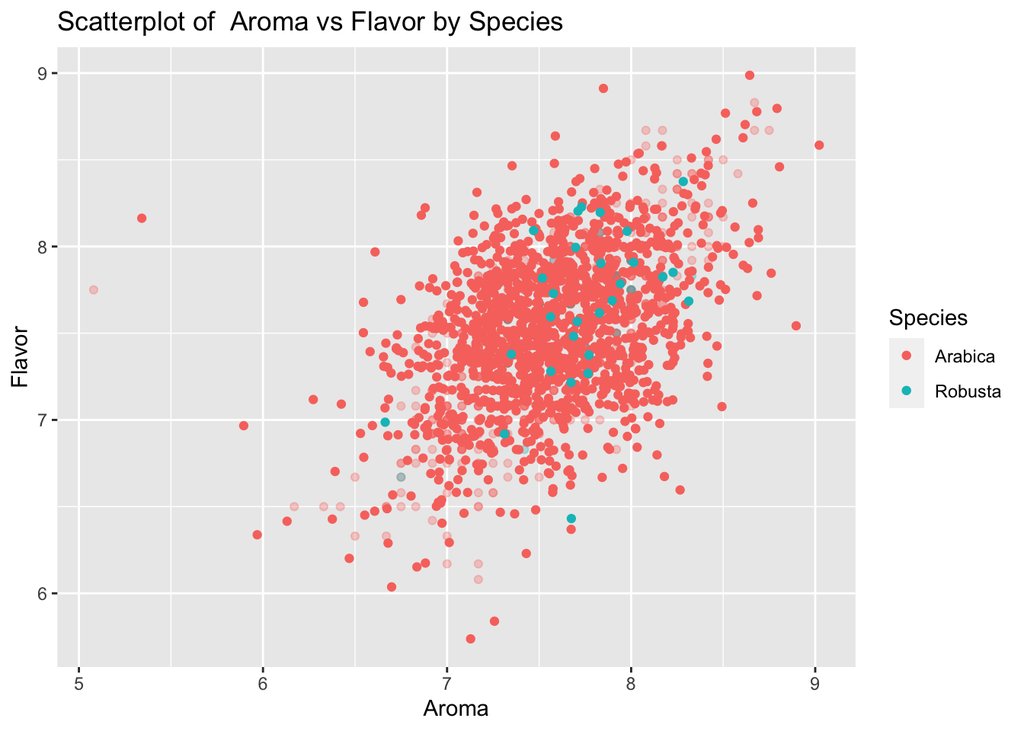

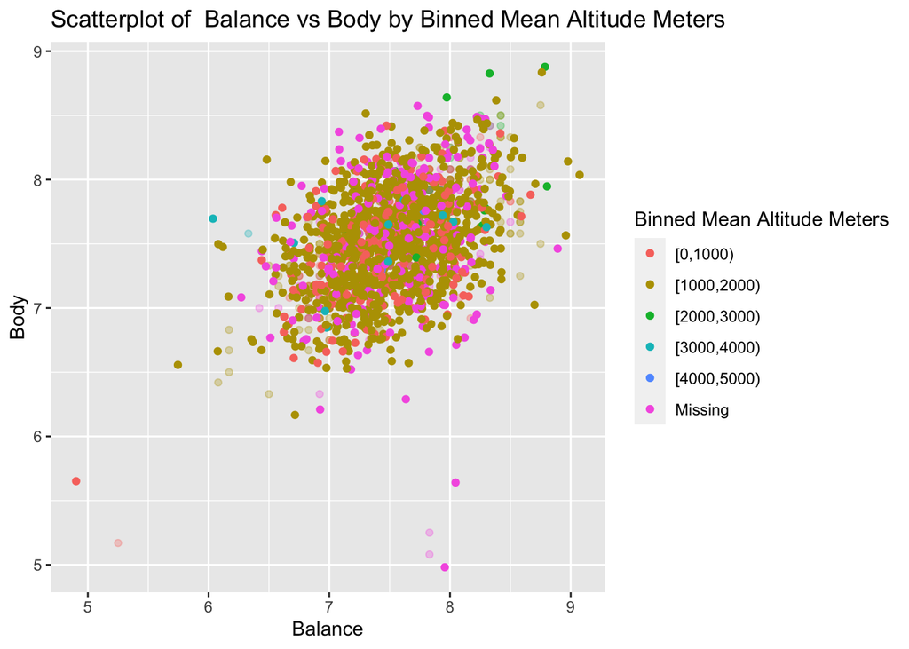

```r
#Use pmap to create scatter plots of x by y grouped by col_group
pmap(list(
  x=c("aroma","balance"),
  y=c("flavor","body"),
  col_group=c("species", "binned_mean_altitude_meters")
  ),
  df = coffee_data2,
  scatter_f)
```